# DAR Defi Team Assignment 4 (Fall 2021)

DeFi Reserve Coins

Kaiwen Min

10/13/2021

# 1 GITHUB UPDATE & SUBMISSION INSTRUCTIONS (Delete before submission!)

For this and subsequent assignments you’ll follow the same basic github steps you used for Assignment 1, ie:

- **Option 1:** Update the copy of your team’s repository currently in your home directory:
  - *This is the preferred option **if** you have already cloned the repository*
  - In the Linux terminal: `git pull origin master`
  - If there are errors, it’s simplest to proceed to “Option 2”
  - If no errors, check your branch: `git branch` (should be something like `dar-rcsid`)
- **Option 2:** Get a fresh copy of your team’s repository:
  - *Do this only if Option 1 fails!*
  - In Linux: `cd ~` to get to your login directory
  - In Linux: `rm -Rf IDEA-Blockchain` (deletes all your previous, uncommited work)
  - In Linux: `git clone https://github.rpi.edu/DataINCITE/IDEA-Blockchain.git`
  - In Linux: `cd IDEA-Blockchain`
  - In Linux: Recreate a personal branch to save your changes to: `git checkout -b dar-rcsid` (replace “rcsid” with your rcsid!)
- Locate and save a personal copy of the assignment notebook:
  - In RStudio “Files” tab, navigate to: `Home > IDEA-Blockchain > DefiResearch > StudentNotebooks > Assignment02`
  - Double-click on `blockchain-assignment2-f21.Rmd` to open
  - Under the “File” menu, “Save as” something like `rcsid-assignment2-f21.Rmd` (replace “rcsid” with your rcsid!)
  - You should see your file appear in the “Files” tab, usually at the bottom
  - Under “More” in the “Files” tab, select “Set as working directory”
- Edit your notebook, saving as you make changes.
  - `cntl-S` works!
- “Knit” your notebook, generating a PDF file:
  - You should see your new PDF appear in the “Files” tab, usually at the bottom
  - “Export” your file (under the “More” menu in the “Files” tab) and save to your local file system
- Add your changed file(s) to your personal branch, and commit:
  - In Linux: `cd ~/IDEA-Blockchain/DefiResearch/StudentNotebooks/Assignment02`
  - In Linux: `git add rcsid-assignment2.*` (replace “rcsid” with your rcsid!)
  - In Linux: `git commit -m "rcsid assignment 2"`
- Push your changes to the remote repository:
  - In Linux: `git push origin dar-rcsid` (replace “rcsid” with your rcsid)
- Issue a pull request:
  - Navigate to https://github.rpi.edu/DataINCITE/IDEA-Blockchain in your browser
  - It should notify you of your recent push and prompt you to make a pull request.
  - If not, find your branch under the popup (defaults to **master**), select and click to issue a pull request
  - One of the instructors
- Upload your downloaded `rcsid-assignment2-f21.pdf` to LMS (replace “rcsid” with your rcsid)
- **Be prepared to share your findings in the DeFi Meeting Thursday.**

# 2 Prepare Transaction Data and Explore

We are directly loading the dataframe from an Rds archive instead of a CSV file to conserve space.

```r
#load Rds (binary version of csv file) into dataframe
# Assumes this notebook is in: ~/IDEA-Blockchain/DefiResearch/StudentNotebooks/Assignment02
df<-read_rds('../../Data/transactions.Rds')

# Let's take a quick look at the first few observation
head(df)
```

|  | amount | borrowRate | borrowRateMode | onBehalfOf | pool | reserve | timestamp | user | type | reservePriceETH | reservePriceUSD | amountUSD | collateralAmount | collateralReserve | principalAmount | principalReserve | reservePriceETHPrincipal | reservePriceUSDPrincipal | reservePriceETHCollateral | reservePriceUSDCollateral | amountUSDPincipal | amountUSDCollateral | borrowRateModeFrom | borrowRateModeTo | stableBorrowRate | variableBorrowRate |
| --- | --- | --- | --- | --- | --- | --- | --- | --- | --- | --- | --- | --- | --- | --- | --- | --- | --- | --- | --- | --- | --- | --- | --- | --- | --- | --- |
| 1 | 41501.63 | 6.274937 | Variable | 8.502518e+47 | 1.034668e+48 | DAI | 1621340435 | 8.502518e+47 | borrow | 2.852900e+14 | 0.9948044 | 41286.00 | NA |  | NA |  | NA | NA | NA | NA | NA | NA |  |  | NA | NA |
| 2 | 7000000.00 | 2.589628 | Variable | 4.635974e+47 | 1.034668e+48 | USDT | 1622477822 | 4.635974e+47 | borrow | 3.812835e+14 | 1.0000000 | 7000000.00 | NA |  | NA |  | NA | NA | NA | NA | NA | NA |  |  | NA | NA |
| 3 | 15000.00 | 8.802541 | Variable | 3.735263e+47 | 1.034668e+48 | USDC | 1619775984 | 3.735263e+47 | borrow | 3.611000e+14 | 1.0043389 | 15065.08 | NA |  | NA |  | NA | NA | NA | NA | NA | NA |  |  | NA | NA |
| 4 | 8193.19 | 48.747052 | Stable | 6.896232e+47 | 1.034668e+48 | USDC | 1615481632 | 6.896232e+47 | borrow | 5.562201e+14 | 0.9993909 | 8188.20 | NA |  | NA |  | NA | NA | NA | NA | NA | NA |  |  | NA | NA |
| 5 | 11000.00 | 3.225055 | Variable | 1.089455e+48 | 1.034668e+48 | USDT | 1626914745 | 1.089455e+48 | borrow | 4.971100e+14 | 1.0000000 | 11000.00 | NA |  | NA |  | NA | NA | NA | NA | NA | NA |  |  | NA | NA |
| 6 | 40000.00 | 5.739208 | Variable | 2.178337e+47 | 1.034668e+48 | USDT | 1620936688 | 2.178337e+47 | borrow | 2.725248e+14 | 1.0000000 | 40000.00 | NA |  | NA |  | NA | NA | NA | NA | NA | NA |  |  | NA | NA |

Now look at the summaries to see the types, values, and missingness (NA’s) of the data.

```r
summary(df)
```

```
##      amount            borrowRate       borrowRateMode     onBehalfOf
##  Min.   :        0   Min.   :    0.0           :386542   Min.   :2.578e+33
##  1st Qu.:       24   1st Qu.:    3.3   Stable  : 18408   1st Qu.:4.174e+47
##  Median :     1427   Median :    3.9   Variable: 76569   Median :7.522e+47
##  Mean   :   191103   Mean   :    9.5                     Mean   :7.592e+47
##  3rd Qu.:    24382   3rd Qu.:   10.8                     3rd Qu.:1.168e+48
##  Max.   :600000000   Max.   :10002.0                     Max.   :1.461e+48
##  NA's   :7289        NA's   :386542                      NA's   :7289
##       pool              reserve         timestamp              user
##  Min.   :9.862e+47   USDC   :105937   Min.   :1.607e+09   Min.   :2.578e+33
##  1st Qu.:1.035e+48   WETH   :105279   1st Qu.:1.615e+09   1st Qu.:4.199e+47
##  Median :1.035e+48   USDT   : 58266   Median :1.621e+09   Median :8.697e+47
##  Mean   :1.034e+48   DAI    : 55211   Mean   :1.620e+09   Mean   :8.082e+47
##  3rd Qu.:1.035e+48   LINK   : 26404   3rd Qu.:1.624e+09   3rd Qu.:1.173e+48
##  Max.   :1.035e+48   WBTC   : 26344   Max.   :1.629e+09   Max.   :1.461e+48
##                      (Other):104078
##           type        reservePriceETH     reservePriceUSD
##  borrow     : 94977   Min.   :1.000e+00   Min.   :0.000e+00
##  deposit    :192006   1st Qu.:2.865e+14   1st Qu.:1.000e+00
##  liquidation:  6289   Median :4.652e+14   Median :1.000e+00
##  redeem     :126705   Mean   :3.458e+23   Mean   :6.774e+08
##  repay      : 60542   3rd Qu.:9.411e+14   3rd Qu.:1.000e+00
##  swap       :  1000   Max.   :1.647e+28   Max.   :4.252e+13
##                       NA's   :7289        NA's   :7289
##    amountUSD         collateralAmount  collateralReserve principalAmount
##  Min.   :        0   Min.   :      0          :475230    Min.   :      0
##  1st Qu.:       70   1st Qu.:      1   WETH   :  2665    1st Qu.:    962
##  Median :     5836   Median :     14   LINK   :  1312    Median :   4362
##  Mean   :   245851   Mean   :   5451   WBTC   :   686    Mean   :  66005
##  3rd Qu.:    49871   3rd Qu.:    250   AAVE   :   333    3rd Qu.:  21533
##  Max.   :754379487   Max.   :4638724   UNI    :   230    Max.   :4475668
##  NA's   :7289        NA's   :475230    (Other):  1063    NA's   :475230
##  principalReserve reservePriceETHPrincipal reservePriceUSDPrincipal
##         :475230   Min.   :1.000e+00        Min.   :    0.0
##  USDC   :  2142   1st Qu.:4.062e+14        1st Qu.:    1.0
##  USDT   :  1549   Median :4.682e+14        Median :    1.0
##  DAI    :  1459   Mean   :1.556e+17        Mean   :  295.6
##  GUSD   :   242   3rd Qu.:5.363e+14        3rd Qu.:    1.0
##  TUSD   :   175   Max.   :4.203e+19        Max.   :83819.1
##  (Other):   722   NA's   :475230           NA's   :475230
```

[output cut: 9 more lines]

```
##  Min.   :      0             :480519            :480519   Min.   :  0.0
##  1st Qu.:      0     Stable  :   471    Stable  :   529   1st Qu.:  9.0
##  Median :    476     Variable:   529    Variable:   471   Median : 10.9
##  Mean   :  37060                                          Mean   : 11.7
##  3rd Qu.:   7457                                          3rd Qu.: 12.0
##  Max.   :5029023                                          Max.   :154.7
##  NA's   :475230                                           NA's   :480519
##  variableBorrowRate
##  Min.   :  0.0
##  1st Qu.:  3.8
##  Median :  3.9
##  Mean   :  5.7
##  3rd Qu.:  5.1
##  Max.   :148.7
##  NA's   :480519
```

First we’ll do some preliminary analysis before we ask detailed questions.

## 2.1 Analyze Transaction Types

Let’s examine the different types of *transactions* present in the data. We’ll make a simple bar plot to visualize the number of each transaction types. “Deposit” is the most common type of transaction, whereas “swaps” are the most rare.

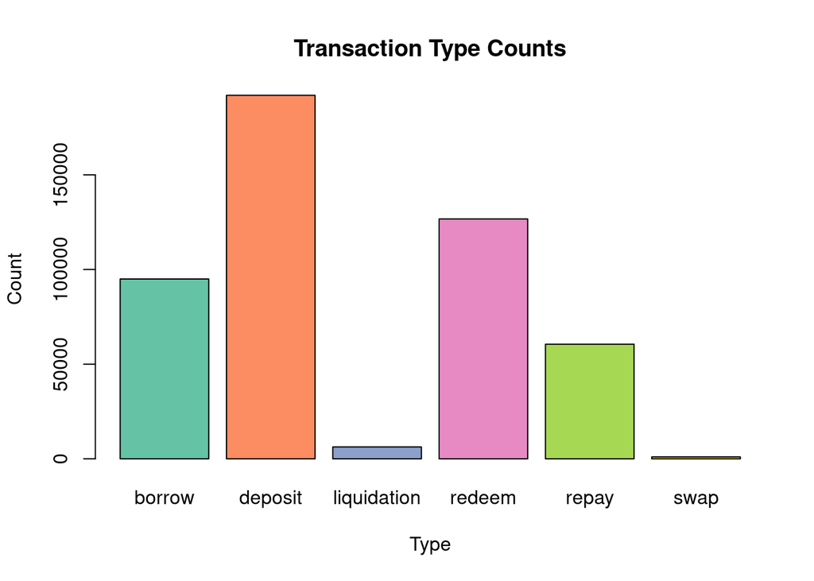

```r
#set color palette
colors = brewer.pal(6,"Set2")

#create barplot
barplot(table(df$type), main='Transaction Type Counts', xlab='Type',ylab='Count',col=colors)
```

There are more “deposits” than “borrows,” because users often need to overcollateralize for loans.

Now we’ll examine the amount of US dollars being used in the different types of transactions. We create box plots for the four types of transactions that have the “amount” feature associated with them, and we visualize the distribution of that column for the different transactions.

We can see that most transactions are completed with very little money.

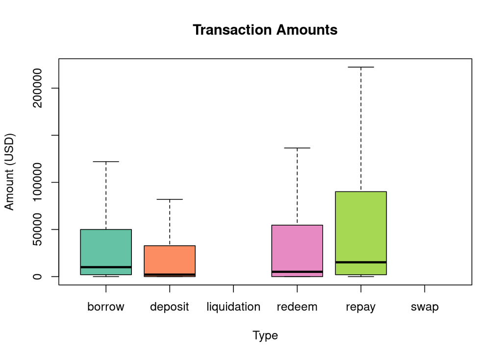

```r
#create boxplot
boxplot(amountUSD~type,data=df,outline=FALSE,col=colors,
        main="Transaction Amounts",xlab="Type",ylab="Amount (USD)")
```

We do find some very large amounts, so it’s helpful to look at this on a log scale.

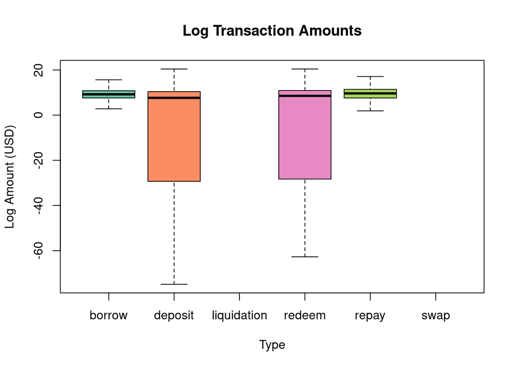

```r
boxplot(log(amountUSD)~type,data=df,outline=FALSE,col=colors,
        main="Log Transaction Amounts",xlab="Type",ylab="Log Amount (USD)")
```

## 2.2 Examine Reserve Coins

There are 50 different “Reserve” coins used in transactions in AAVE. Let’s create a table of those reserve coins with at least 500 transactions and rank order them by their volume.

```r
# Use deplyr to drop NA reserves, add the counts and then kep only the top 20
reservecoins <- df %>%  drop_na(reserve) %>%
  count(reserve) %>%
  arrange(-n) %>%
  head(30)

# Add the rank to help keep track of the reserve coins
reservecoins <- reservecoins %>%
  mutate(rank=1:nrow(reservecoins),.before=reserve)

# List the results nicely with kable()
kable(reservecoins)
```

| rank | reserve | n |
| --- | --- | --- |
| 1 | USDC | 105937 |
| 2 | WETH | 105279 |
| 3 | USDT | 58266 |
| 4 | DAI | 55211 |
| 5 | LINK | 26404 |
| 6 | WBTC | 26344 |
| 7 | AAVE | 12174 |
| 8 | CRV | 10593 |
| 9 | UNI | 7547 |
| 10 | XSUSHI | 7337 |
| 11 | SNX | 6938 |
| 12 | SUSD | 6542 |
| 13 |  | 6289 |
| 14 | GUSD | 6009 |
| 15 | YFI | 5919 |
| 16 | BUSD | 4863 |
| 17 | TUSD | 3317 |
| 18 | BAL | 3152 |
| 19 | MKR | 3101 |
| 20 | REN | 2638 |
| 21 | ENJ | 2457 |
| 22 | MANA | 1993 |
| 23 | AmmWETH | 1778 |
| 24 | RAI | 1532 |
| 25 | AMPL | 1497 |
| 26 | AmmUSDC | 1405 |
| 27 | BAT | 1377 |
| 28 | KNC | 1349 |
| 29 | AmmDAI | 1266 |
| 30 | ZRX | 905 |

Let’s look at the number of transactions types for each currency.

```r
TopcoinSummary <- df %>% filter(reserve %in% reservecoins$reserve) %>%
  group_by(reserve) %>%
  count(type) %>%
  mutate(percent = n/sum(n)*100)

kable(TopcoinSummary)
```

| reserve | type | n | percent |
| --- | --- | --- | --- |
|  | liquidation | 6289 | 100.0000000 |
| AAVE | borrow | 2 | 0.0164285 |
| AAVE | deposit | 7028 | 57.7295876 |
| AAVE | redeem | 5141 | 42.2293412 |
| AAVE | repay | 3 | 0.0246427 |
| AmmDAI | borrow | 529 | 41.7851501 |
| AmmDAI | deposit | 289 | 22.8278041 |
| AmmDAI | redeem | 209 | 16.5086888 |
| AmmDAI | repay | 239 | 18.8783570 |
| AmmUSDC | borrow | 283 | 20.1423488 |
| AmmUSDC | deposit | 537 | 38.2206406 |
| AmmUSDC | redeem | 369 | 26.2633452 |
| AmmUSDC | repay | 216 | 15.3736655 |
| AmmWETH | borrow | 180 | 10.1237345 |
| AmmWETH | deposit | 1014 | 57.0303712 |
| AmmWETH | redeem | 473 | 26.6029246 |
| AmmWETH | repay | 111 | 6.2429696 |
| AMPL | borrow | 438 | 29.2585170 |
| AMPL | deposit | 601 | 40.1469606 |
| AMPL | redeem | 301 | 20.1068804 |
| AMPL | repay | 157 | 10.4876420 |
| BAL | borrow | 215 | 6.8210660 |
| BAL | deposit | 2171 | 68.8769036 |
| BAL | redeem | 612 | 19.4162437 |
| BAL | repay | 154 | 4.8857868 |
| BAT | borrow | 158 | 11.4742193 |
| BAT | deposit | 750 | 54.4662309 |
| BAT | redeem | 335 | 24.3282498 |
| BAT | repay | 132 | 9.5860566 |
| BAT | swap | 2 | 0.1452433 |

[output cut: 101 more lines]

## 2.3 Look at Sample User Transaction Histories

Finally, we will examine the transaction history of different users. To do this, we will select 3 random users from the data who have completed between 100 and 300 transactions. Then, we create swarmplots displaying the different types of transactions those users made over time.

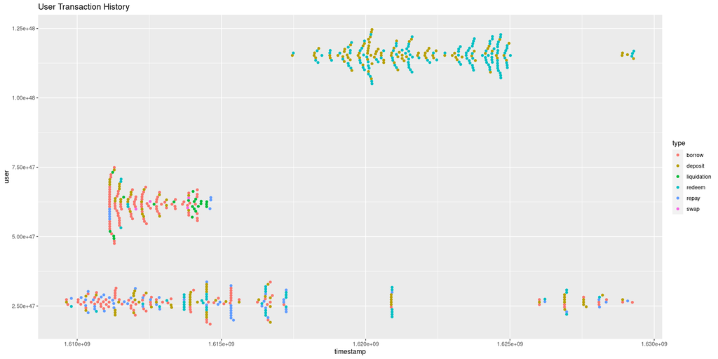

```r
#set seed
set.seed(1)

# Select three random users that have between 100 and 300 transactions
users<-vector(length=3)
count<-0
while(count<=3){
  success<-FALSE
  while(!success){
    #get random user
    ruser<-sample(df$user,1)

    #check for valid number of transactions
    length<-nrow(filter(df,user==ruser))
    if (length>100 && length<300){
      users[count]=ruser
      success<-TRUE
      count<-count+1
    }
  }
}
df.rusers<-filter(df, user %in%users)

# Create a "swarmplot"

ggplot(df.rusers,aes(user, timestamp,color=type)) +
        geom_beeswarm(cex=1)+
        coord_flip()+
        ggtitle("User Transaction History")
```

Observation: *Users have very different transactions patterns, which we will try to better understand.*

# 3 Activities

##$\color{blue}{Exercise~1} (10 pts)$

1. Divide the top 20 reserve coins between your team members so each team member has the same amount of coins; feel free to add or subtract coins if necessary.
2. Look up your coins on the internet to find out what they are. ProTip: Look them up on http://defipulse.com to see their *Total Value Locked (TVL)*.
3. Examine the percentage of transaction types for your coins. Hypothesize why a given coin might have more of one type of transaction than another.
4. *Prepare one slide with the findings for each of your coins.* (one slide summarizing each coin)
5. Coordinate with your team, to combine each of your member’s coin descriptions into a single presentation. Please develop a common format or template for presenting your coin summaries so that the common information for a coin (e.g. TVL) is shown in the same format. (Your slide summaries should look the same!)
6. Be prepared to present your team presentation to your client in class on Thursday 9/16.

##$\color{blue}{Exercise~2} (10 pts)$

1. Perform a “creative exploration” of some aspect of the Defi data that you find interesting. Add your work in this notebook. *Your work should include at least one data visualization.*
2. Put your work in this notebook.
3. Write a paragraph describing your findings in the context of DeFi.
4. Be prepared to share (2 minutes) in team meeting.
5. *You’ll receive extra credit for work that goes “above and beyond” this assignment!*

```r
#set seed


df.borrow <- df %>% filter(!is.na(borrowRate)) %>%
  filter(type == "borrow") %>%
  filter(borrowRate <= 50) %>%
  filter(amountUSD <= 10000000) %>%
  filter(1 <= amountUSD)

summary(df.borrow$borrowRate)
```

```
##    Min. 1st Qu.  Median    Mean 3rd Qu.    Max.
##   0.000   3.439   3.970   8.422  10.980  49.992
```

```r
#df.borrow.variable <- df.borrow %>% filter(borrowRateMode == "Variable")
#summary(df.borrow.variable$borrowRate)
#summary(df.borrow.variable$amountUSD)
#df.borrow.stable <- df.borrow %>% filter(borrowRateMode == "Stable")
#summary(df.borrow.stable$borrowRate)
#summary(df.borrow.stable$amountUSD)



summary(df.borrow$amountUSD)
```

```
##     Min.  1st Qu.   Median     Mean  3rd Qu.     Max.
##        1     3011    11996   146080    56576 10000000
```

```r
borrowRateModeSummary <- df.borrow %>% filter(reserve %in% reservecoins$reserve) %>%
  group_by(reserve) %>%
  count(borrowRateMode) %>%
  mutate(percent = n/sum(n)*100)

kable(borrowRateModeSummary)
```

| reserve | borrowRateMode | n | percent |
| --- | --- | --- | --- |
| AAVE | Variable | 1 | 100.00000 |
| AmmDAI | Variable | 520 | 100.00000 |
| AmmUSDC | Variable | 281 | 100.00000 |
| AMPL | Variable | 424 | 100.00000 |
| BAL | Variable | 203 | 100.00000 |
| BAT | Stable | 27 | 17.64706 |
| BAT | Variable | 126 | 82.35294 |
| BUSD | Variable | 1665 | 100.00000 |
| CRV | Variable | 886 | 100.00000 |
| DAI | Stable | 3391 | 24.25435 |
| DAI | Variable | 10590 | 75.74565 |
| ENJ | Stable | 134 | 58.26087 |
| ENJ | Variable | 96 | 41.73913 |
| GUSD | Variable | 2255 | 100.00000 |
| KNC | Stable | 32 | 26.66667 |
| KNC | Variable | 88 | 73.33333 |
| LINK | Stable | 171 | 12.96437 |
| LINK | Variable | 1148 | 87.03563 |
| MANA | Stable | 41 | 19.24883 |
| MANA | Variable | 172 | 80.75117 |
| MKR | Stable | 35 | 19.23077 |
| MKR | Variable | 147 | 80.76923 |
| RAI | Variable | 320 | 100.00000 |
| REN | Stable | 103 | 55.67568 |
| REN | Variable | 82 | 44.32432 |
| SNX | Variable | 413 | 100.00000 |
| SUSD | Variable | 1194 | 100.00000 |
| TUSD | Stable | 327 | 35.81599 |
| TUSD | Variable | 586 | 64.18401 |
| UNI | Variable | 561 | 100.00000 |
| USDC | Stable | 8873 | 25.23606 |
| USDC | Variable | 26287 | 74.76394 |
| USDT | Stable | 4495 | 20.28796 |
| USDT | Variable | 17661 | 79.71204 |
| WBTC | Stable | 159 | 7.79794 |
| WBTC | Variable | 1880 | 92.20206 |
| XSUSHI | Variable | 237 | 100.00000 |
| YFI | Variable | 334 | 100.00000 |
| ZRX | Stable | 15 | 20.27027 |
| ZRX | Variable | 59 | 79.72973 |

```r
userSummary <- df.borrow %>% filter(reserve %in% reservecoins$reserve) %>%
  group_by(user)
head(userSummary)
```

| amount | borrowRate | borrowRateMode | onBehalfOf | pool | reserve | timestamp | user | type | reservePriceETH | reservePriceUSD | amountUSD | collateralAmount | collateralReserve | principalAmount | principalReserve | reservePriceETHPrincipal | reservePriceUSDPrincipal | reservePriceETHCollateral | reservePriceUSDCollateral | amountUSDPincipal | amountUSDCollateral | borrowRateModeFrom | borrowRateModeTo | stableBorrowRate | variableBorrowRate |
| --- | --- | --- | --- | --- | --- | --- | --- | --- | --- | --- | --- | --- | --- | --- | --- | --- | --- | --- | --- | --- | --- | --- | --- | --- | --- |
| 41501.63 | 6.274937 | Variable | 8.502518e+47 | 1.034668e+48 | DAI | 1621340435 | 8.502518e+47 | borrow | 2.852900e+14 | 0.9948044 | 41286.00 | NA |  | NA |  | NA | NA | NA | NA | NA | NA |  |  | NA | NA |
| 7000000.00 | 2.589628 | Variable | 4.635974e+47 | 1.034668e+48 | USDT | 1622477822 | 4.635974e+47 | borrow | 3.812835e+14 | 1.0000000 | 7000000.00 | NA |  | NA |  | NA | NA | NA | NA | NA | NA |  |  | NA | NA |
| 15000.00 | 8.802541 | Variable | 3.735263e+47 | 1.034668e+48 | USDC | 1619775984 | 3.735263e+47 | borrow | 3.611000e+14 | 1.0043389 | 15065.08 | NA |  | NA |  | NA | NA | NA | NA | NA | NA |  |  | NA | NA |
| 8193.19 | 48.747052 | Stable | 6.896232e+47 | 1.034668e+48 | USDC | 1615481632 | 6.896232e+47 | borrow | 5.562201e+14 | 0.9993909 | 8188.20 | NA |  | NA |  | NA | NA | NA | NA | NA | NA |  |  | NA | NA |
| 11000.00 | 3.225055 | Variable | 1.089455e+48 | 1.034668e+48 | USDT | 1626914745 | 1.089455e+48 | borrow | 4.971100e+14 | 1.0000000 | 11000.00 | NA |  | NA |  | NA | NA | NA | NA | NA | NA |  |  | NA | NA |
| 40000.00 | 5.739208 | Variable | 2.178337e+47 | 1.034668e+48 | USDT | 1620936688 | 2.178337e+47 | borrow | 2.725248e+14 | 1.0000000 | 40000.00 | NA |  | NA |  | NA | NA | NA | NA | NA | NA |  |  | NA | NA |

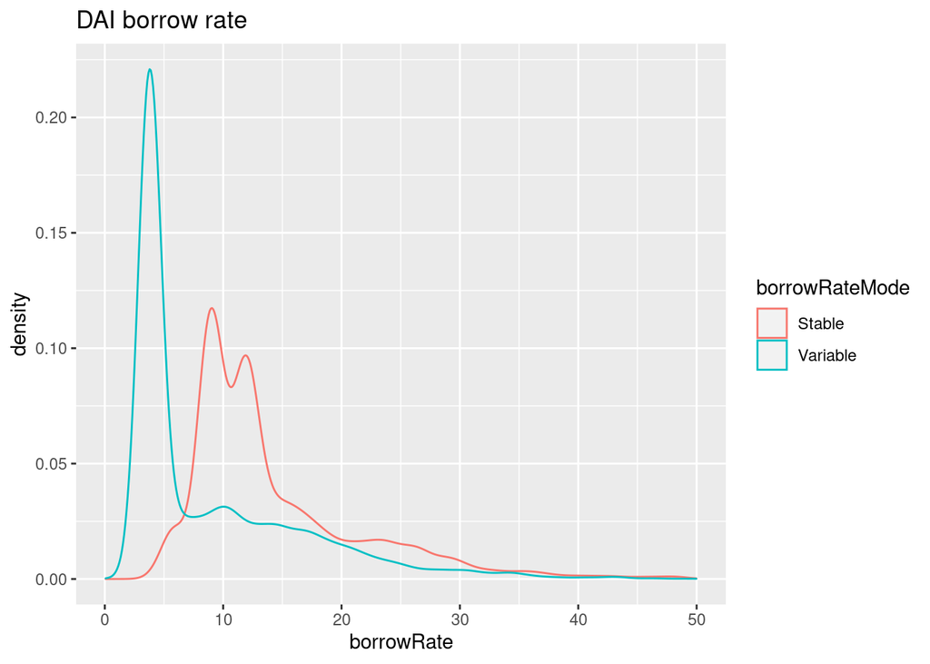

```r
df.borrow.DAI <- df.borrow %>% filter(reserve == "DAI")
#summary(df.borrow.DAI)
ggplot(df.borrow.DAI,aes(borrowRate, color = borrowRateMode)) +
  ggtitle("DAI borrow rate")+
  geom_density()
```

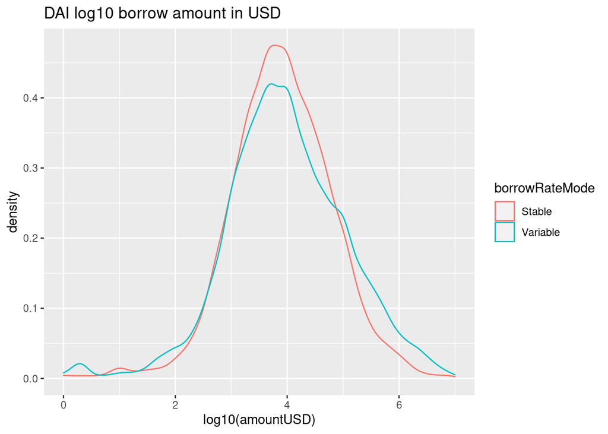

```r
ggplot(df.borrow.DAI,aes(log10(amountUSD), color = borrowRateMode)) +
  ggtitle("DAI log10 borrow amount in USD")+
  geom_density()
```

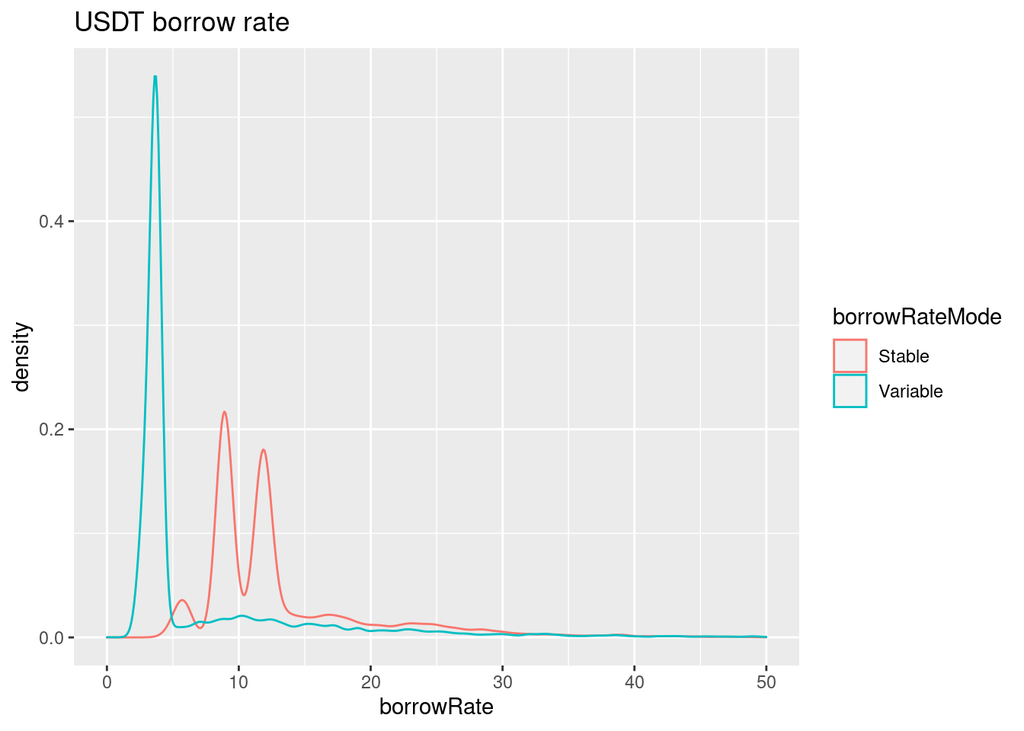

```r
df.borrow.USDT <- df.borrow %>% filter(reserve == "USDT")
#summary(df.borrow.USDT)
ggplot(df.borrow.USDT,aes(borrowRate, color = borrowRateMode)) +
  ggtitle("USDT borrow rate")+
  geom_density()
```

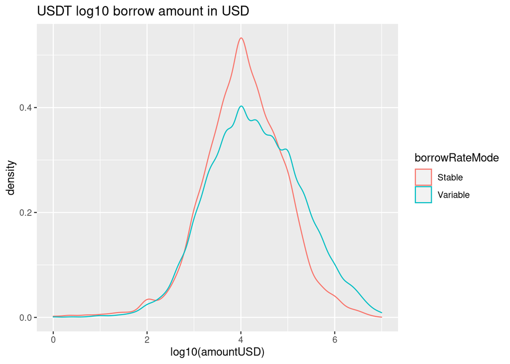

```r
ggplot(df.borrow.USDT,aes(log10(amountUSD), color = borrowRateMode)) +
  ggtitle("USDT log10 borrow amount in USD")+
  geom_density()
```

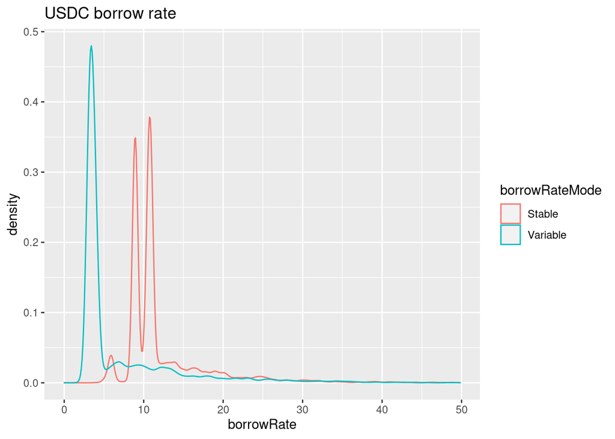

```r
df.borrow.USDC <- df.borrow %>% filter(reserve == "USDC")
#summary(df.borrow.USDC)
ggplot(df.borrow.USDC,aes(borrowRate, color = borrowRateMode)) +
  ggtitle("USDC borrow rate")+
  geom_density()
```

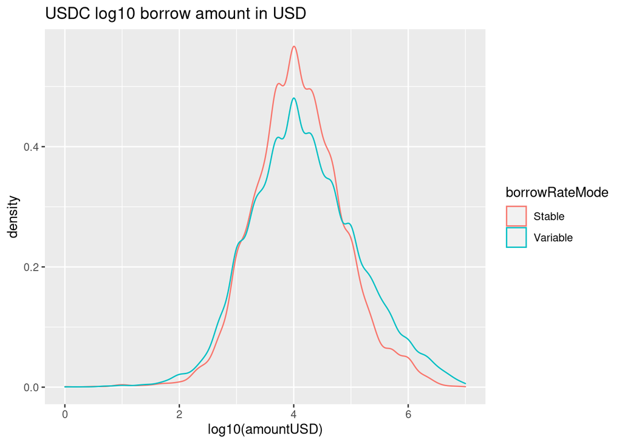

```r
ggplot(df.borrow.USDC,aes(log10(amountUSD), color = borrowRateMode)) +
  ggtitle("USDC log10 borrow amount in USD")+
  geom_density()
```

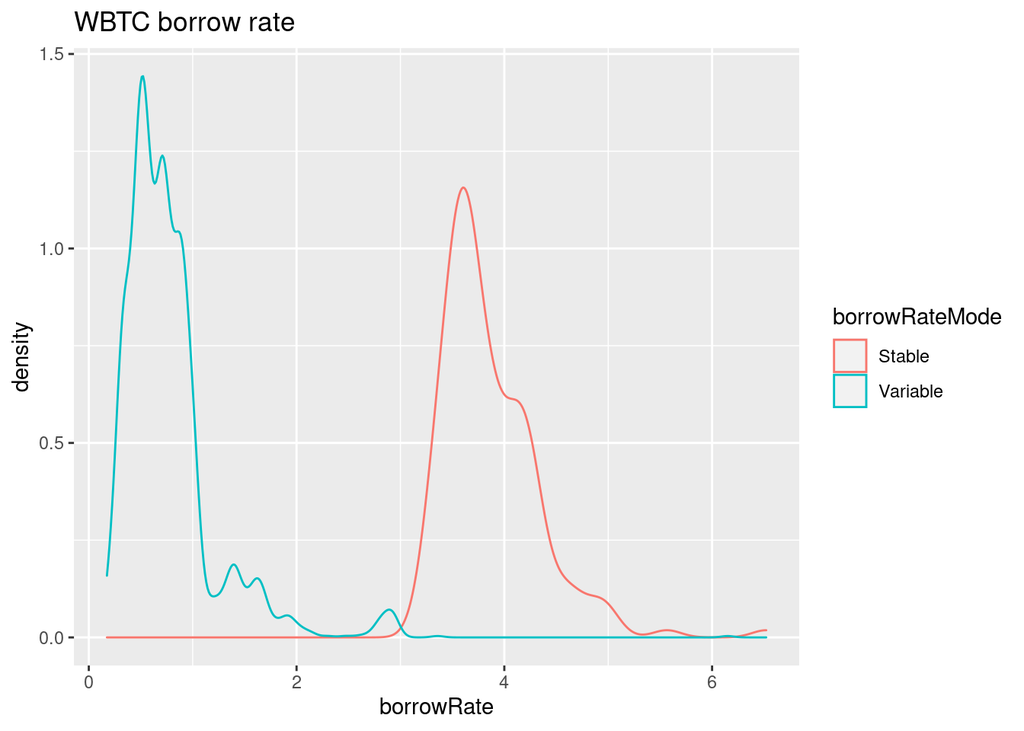

```r
df.borrow.WBTC <- df.borrow %>% filter(reserve == "WBTC")
#summary(df.borrow.WBTC)
ggplot(df.borrow.WBTC,aes(borrowRate, color = borrowRateMode)) +
  ggtitle("WBTC borrow rate")+
  geom_density()
```

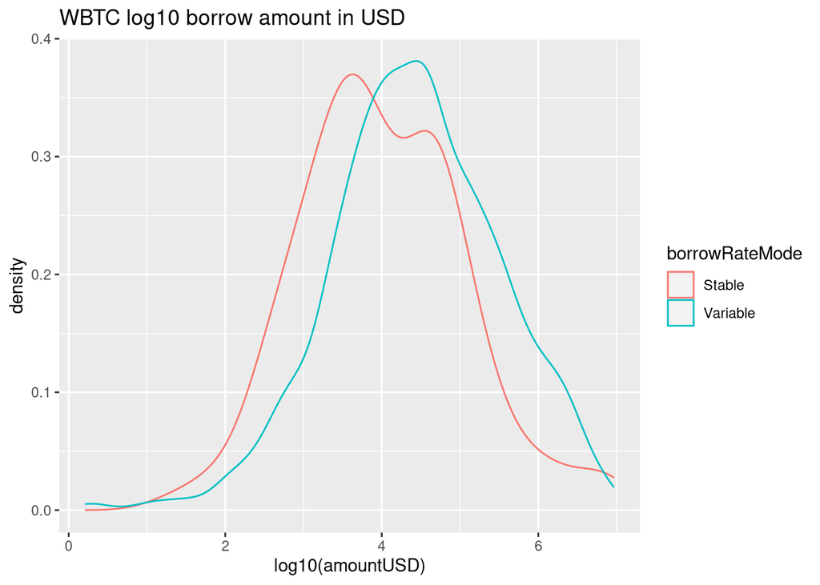

```r
ggplot(df.borrow.WBTC,aes(log10(amountUSD), color = borrowRateMode)) +
  ggtitle("WBTC log10 borrow amount in USD")+
  geom_density()
```

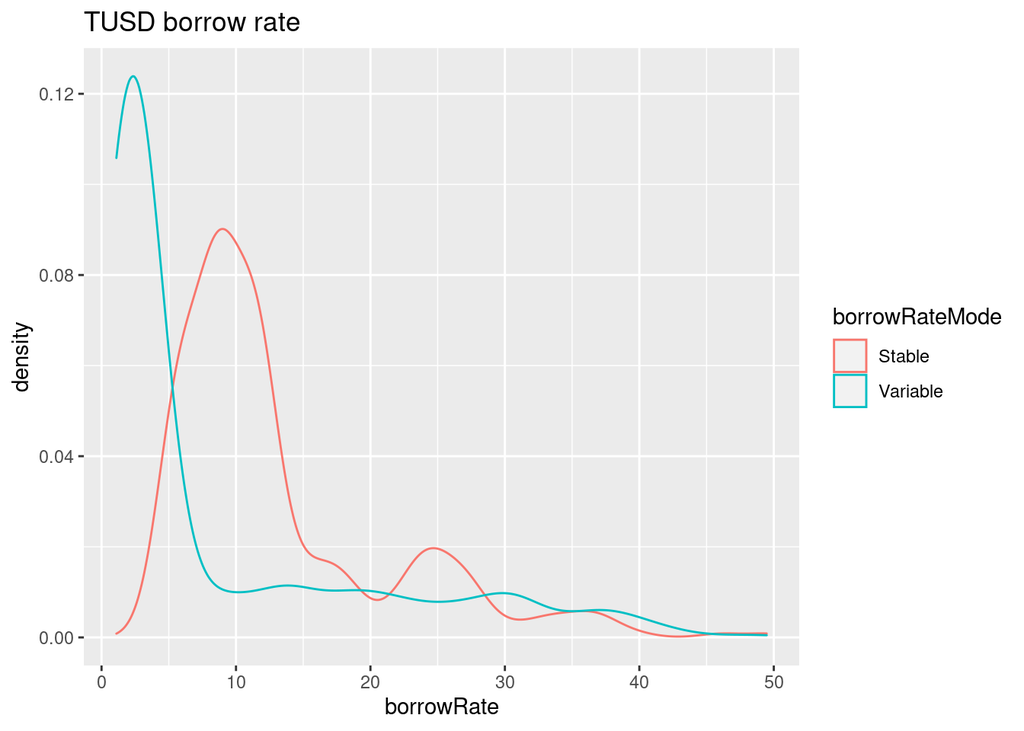

```r
df.borrow.TUSD <- df.borrow %>% filter(reserve == "TUSD")
#summary(df.borrow.TUSD)
ggplot(df.borrow.TUSD,aes(borrowRate, color = borrowRateMode)) +
  ggtitle("TUSD borrow rate")+
  geom_density()
```

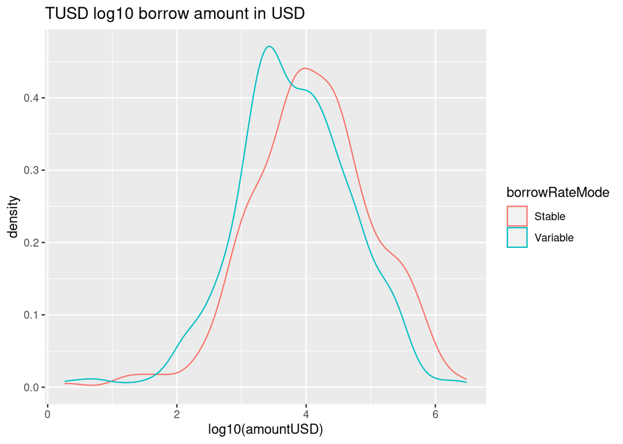

```r
ggplot(df.borrow.TUSD,aes(log10(amountUSD), color = borrowRateMode)) +
  ggtitle("TUSD log10 borrow amount in USD")+
  geom_density()
```

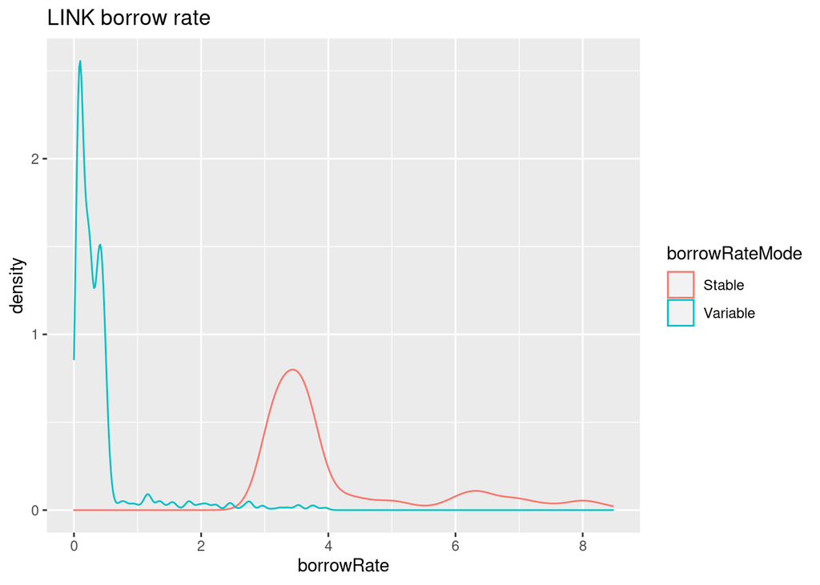

```r
df.borrow.LINK <- df.borrow %>% filter(reserve == "LINK")
#summary(df.borrow.LINK)
ggplot(df.borrow.LINK,aes(borrowRate, color = borrowRateMode)) +
  ggtitle("LINK borrow rate")+
  geom_density()
```

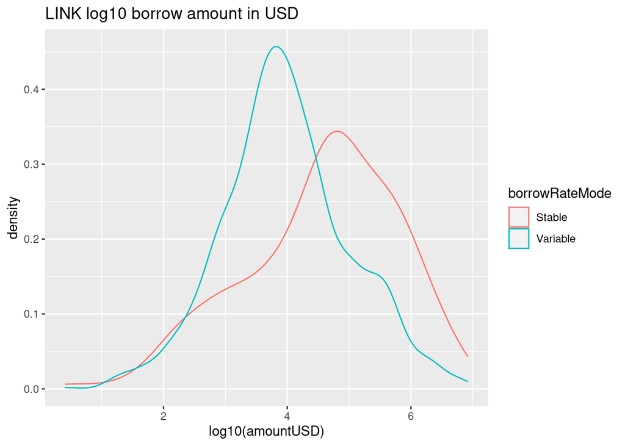

```r
ggplot(df.borrow.LINK,aes(log10(amountUSD), color = borrowRateMode)) +
  ggtitle("LINK log10 borrow amount in USD")+
  geom_density()
```

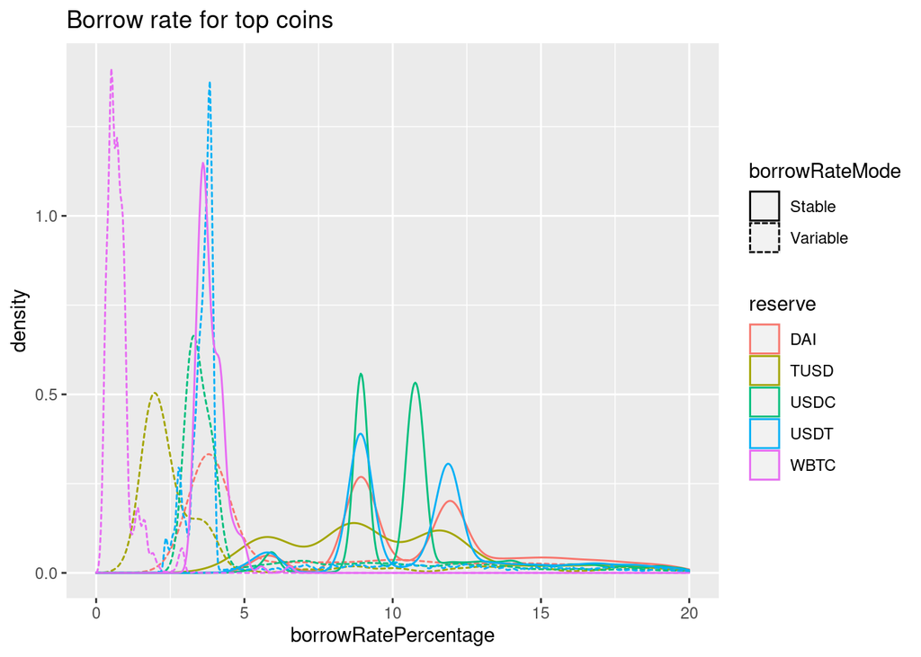

```r
df.borrow.new2 <- df.borrow %>%
  filter(reserve == "USDC" | reserve == "USDT" | reserve == "DAI" | reserve == "WBTC" | reserve == "TUSD") %>%
  filter(borrowRate <= 20) %>%
  rename(borrowRatePercentage = borrowRate)


ggplot(df.borrow.new2,aes(borrowRatePercentage, color = reserve, linetype = borrowRateMode)) +
  ggtitle("Borrow rate for top coins")+
  geom_density()
```

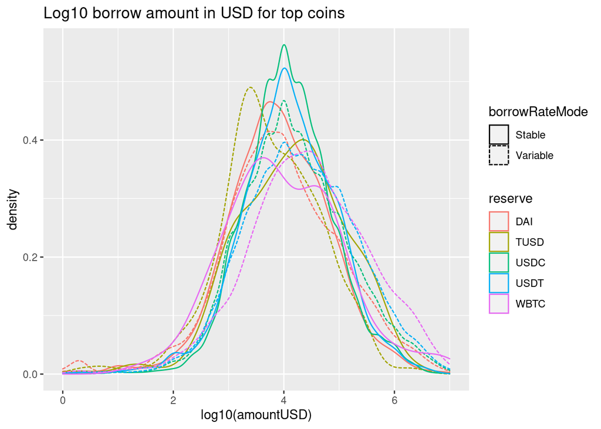

```r
ggplot(df.borrow.new2,aes(log10(amountUSD), color = reserve, linetype = borrowRateMode)) +
  ggtitle("Log10 borrow amount in USD for top coins")+
  geom_density()
```